# Distributions exercises

Jon Chernus

Here are the packages you need. You may need to install scRNAseq from Bioconductor with `BiocManager::install("scRNAseq")`.

# Setup

## Packages

```r
# Install these if needed
# BiocManager::install("scRNAseq")
library("tidyverse")
library("scRNAseq")
```

## Data

We’ll use some (real) scRNAseq data from 20 samples.

```r
# Set up data
counts <- assay(SegerstolpePancreasData(), "counts")
d <- as.data.frame(counts[,201])
for (i in 1:19) {
  d <- cbind(d,counts[,200+i])
}
names(d) <- paste0("sample",1:ncol(d))
head(d)
```

```
##   sample1 sample2 sample3 sample4 sample5 sample6 sample7 sample8 sample9
## 1       0       0      71       0       0       0       0       0       0
## 2       0       0       0       0       0       0       0       0       0
## 3      71      71       0       0       0       0       0      29       0
## 4       0       0       0       0       0       0       0       0       0
## 5       0       0       0       0       0       1       0       0       0
## 6       0       0       0       0       0       0       0       0       0
##   sample10 sample11 sample12 sample13 sample14 sample15 sample16 sample17
## 1        6        0        0        0        0        0        0        0
## 2        0        0       58        0        0        0       36        0
## 3        0        0        0        0        8        0        0        0
## 4        0        0        0        0       71        0        0        0
## 5       98        0        7        0       10      210        0        0
## 6        0        0        0        0        0        0        0        0
##   sample18 sample19 sample20
## 1        0        0       12
## 2        0        0        0
## 3        0        0        0
## 4        0        0        0
## 5        0        1        0
## 6        0        0        0
```

```r
dim(d)
```

```
## [1] 26179    20
```

# Exercises

## One-variable histograms

First, make a histogram of the raw counts for one of the samples.

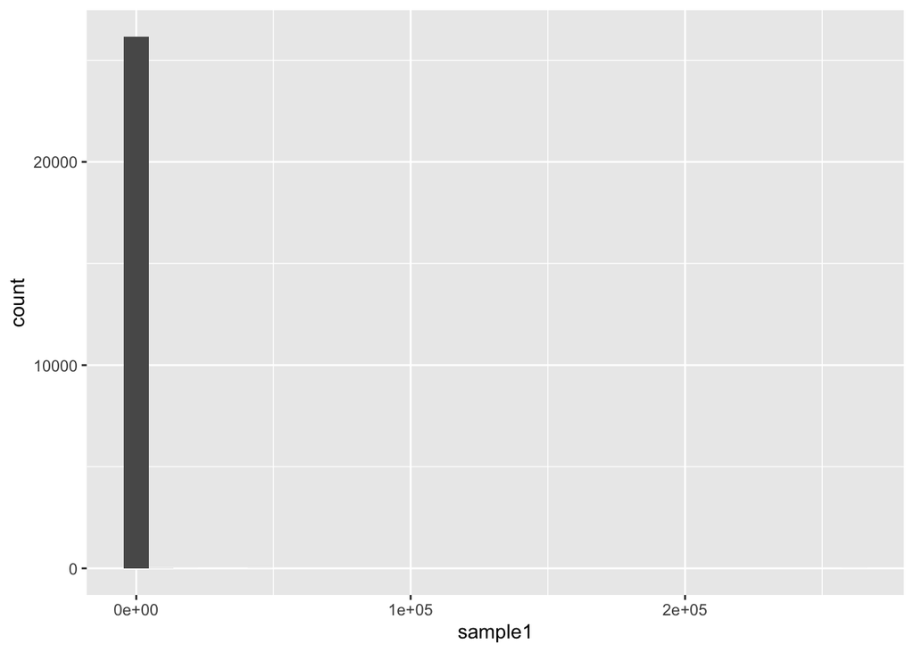

```r
d %>%
  ggplot() +
  geom_histogram(aes(x=sample1))
```

What’s wrong with this histogram? Without changing the bins (yet), change the plot or data in a way to make the plot more informative. (Hint: transform the data.)

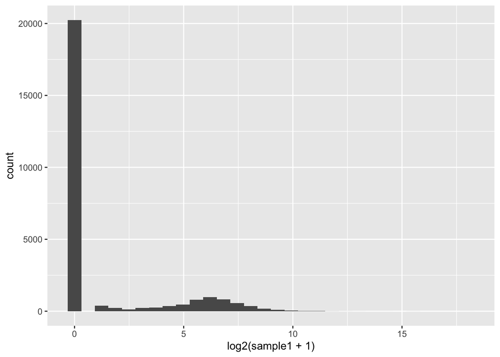

```r
d %>%
  ggplot() +
  geom_histogram(aes(x=log2(sample1+1)))
```

One bin still dominates. But what if we want to simply categorize the genes into two bins, “undetected” and “detected”? See if simply telling `geom_histogram` to use 2 bins works.

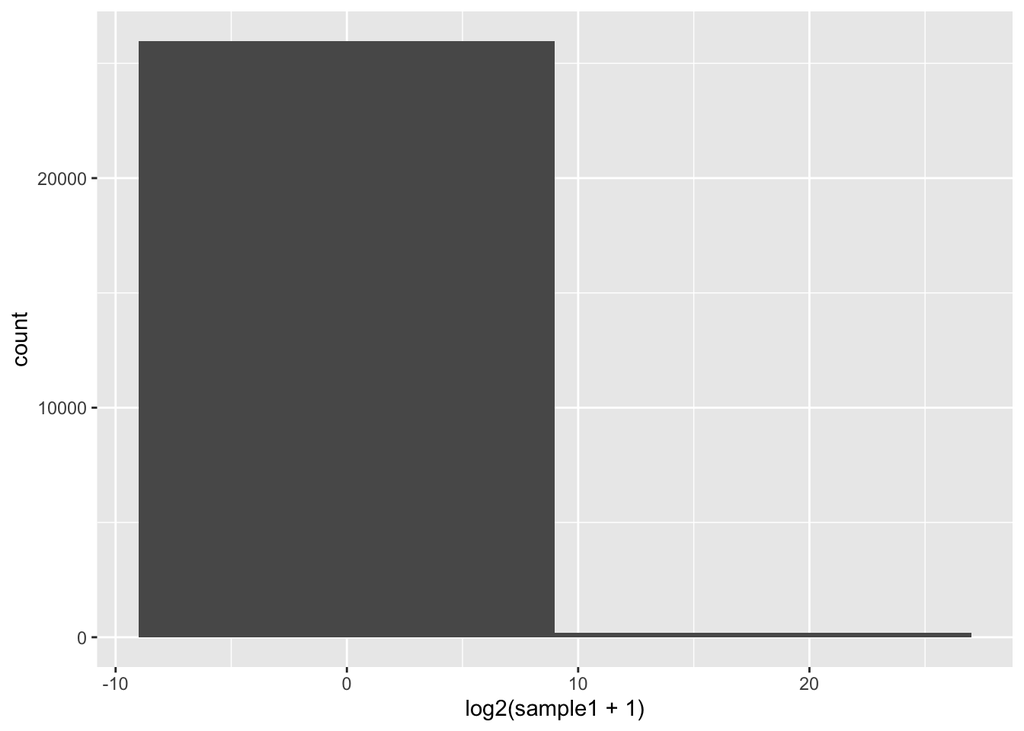

```r
d %>%
  ggplot() +
  geom_histogram(aes(x=log2(sample1+1)), bins=2)
```

Did that do what you intended? Is there one “undetected” and one “detected” bin? Time to try a different `geom_histogram` parameter, `breaks`, instead of `bins`. Note that `breaks` needs to specify a vector. Note this will not create equally wide bins.

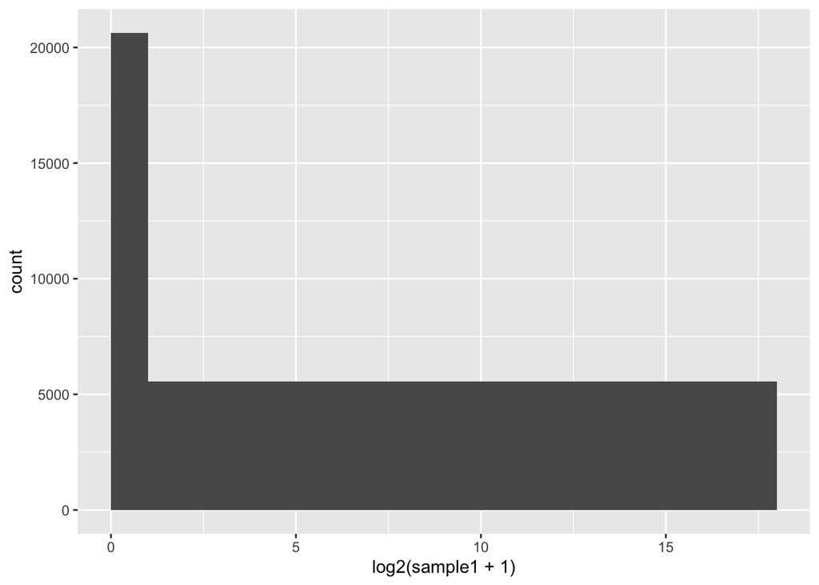

```r
d %>%
  ggplot() +
  geom_histogram(aes(x=log2(sample1+1)),
                 breaks = c(-0,
                            1,
                            max(log2(d$sample1+1))
                            )
                 )
```

Not try using uniform bin widths of 1. Notice that (almost) no matter how you specify the bins, the x-axis seems to extend out past 10, although there are apparently no bins. What is happening there?

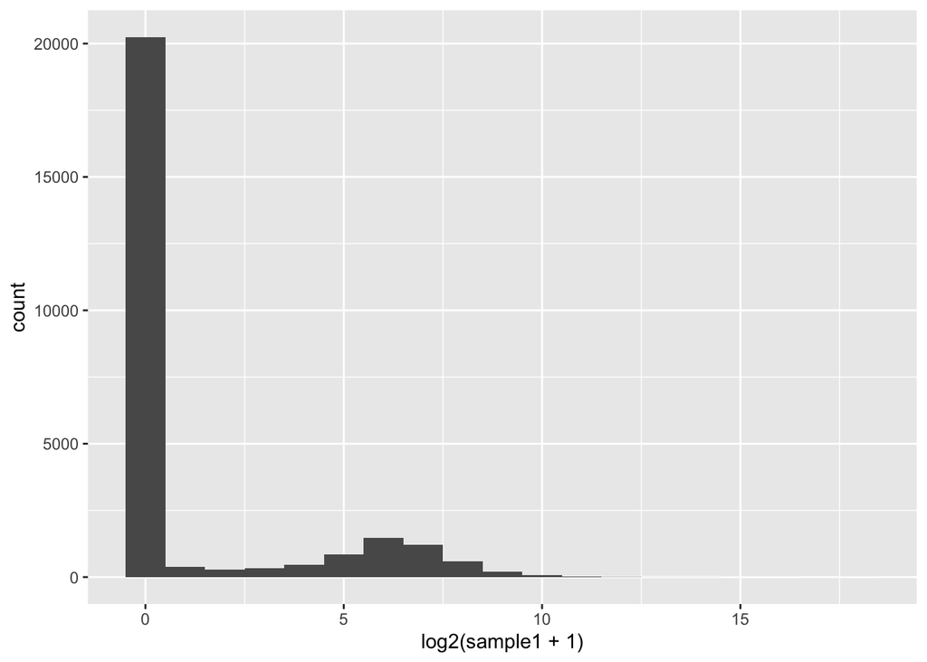

```r
d %>%
  ggplot() +
  geom_histogram(aes(x=log2(sample1+1)), binwidth=1)
```

Finally, try plotting the data without the undetected genes.

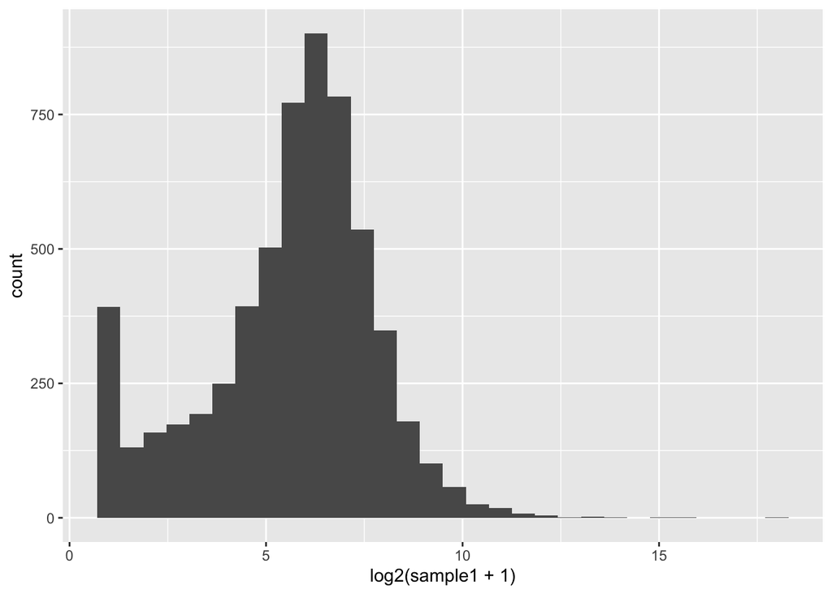

```r
d %>%
  filter(sample1 > 0) %>%
  ggplot() +
  geom_histogram(aes(x=log2(sample1+1)))
```

## Histograms with more than 1 variable

Now let’s compare the distributions of several variables. For a moment, imagine you wanted to plot histograms for sample1 and sample2 in the same plot. You would still want to include `geom_histogram()` with expression assigned to the `x` aesthetic. What would you need in order to draw separate distributions for sample1 and sample2?

Take a moment to look at the data and think about what you’d try. Use this chunk as a sandbox for a moment before moving on to the answer. (You might must want to simply do `head(d))`.)

```r
head(d)
```

```
##   sample1 sample2 sample3 sample4 sample5 sample6 sample7 sample8 sample9
## 1       0       0      71       0       0       0       0       0       0
## 2       0       0       0       0       0       0       0       0       0
## 3      71      71       0       0       0       0       0      29       0
## 4       0       0       0       0       0       0       0       0       0
## 5       0       0       0       0       0       1       0       0       0
## 6       0       0       0       0       0       0       0       0       0
##   sample10 sample11 sample12 sample13 sample14 sample15 sample16 sample17
## 1        6        0        0        0        0        0        0        0
## 2        0        0       58        0        0        0       36        0
## 3        0        0        0        0        8        0        0        0
## 4        0        0        0        0       71        0        0        0
## 5       98        0        7        0       10      210        0        0
## 6        0        0        0        0        0        0        0        0
##   sample18 sample19 sample20
## 1        0        0       12
## 2        0        0        0
## 3        0        0        0
## 4        0        0        0
## 5        0        1        0
## 6        0        0        0
```

“The answer” is that it’s impossible to do what we want with the data in this shape. Right now, the data are in “wide” format. A consequence is that there is no **single** column identifying what sample each expression belongs to. But that is exactly what we need in order to draw separate histograms in different colors for the different samples!

Here’s a toy example of what this means:

```
Wide format:

            sample1   sample2   sample3
(gene 1)    5         10        15
(gene 2)    0         12        0



Same data in long format:

expression    gene    sample
5             1       1
10            1       2
15            1       3
0             2       1
12            2       2
0             2       3
```

The following chunk converts the data into long format with the `pivot_longer` function.

```r
dlong <- d %>%
  mutate(gene=row_number()) %>%
  pivot_longer(,
               cols=sample1:sample20,
               names_to="sample",
               values_to="expression")
head(dlong, n=20)
```

```
## # A tibble: 20 × 3
##     gene sample   expression
##    <int> <chr>         <dbl>
##  1     1 sample1           0
##  2     1 sample2           0
##  3     1 sample3          71
##  4     1 sample4           0
##  5     1 sample5           0
##  6     1 sample6           0
##  7     1 sample7           0
##  8     1 sample8           0
##  9     1 sample9           0
## 10     1 sample10          6
## 11     1 sample11          0
## 12     1 sample12          0
## 13     1 sample13          0
## 14     1 sample14          0
## 15     1 sample15          0
## 16     1 sample16          0
## 17     1 sample17          0
## 18     1 sample18          0
## 19     1 sample19          0
## 20     1 sample20         12
```

Now that you have the `sample` variable, make a single plot showing histograms for 3 samples. Include the `position` argument of `geom_histogram`, trying these 3 values for it: `identity`, `stack`, and `dodge`.

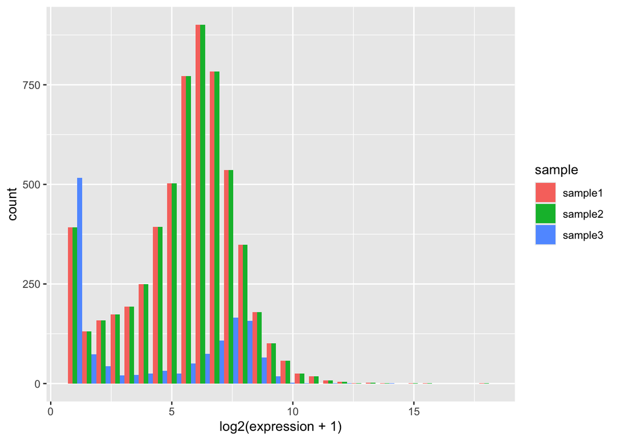

```r
dlong %>%
  filter(sample %in% c("sample1", "sample2", "sample3")) %>%
  filter(expression > 0) %>%
  ggplot() +
  geom_histogram(
    aes(x=log2(expression+1), fill=sample), position="dodge")
```